# Estudio de la pobreza mundial en el año 2018

#### P4_ENTREGA

### Introduccion

La pobreza es definida, según las Naciones Unidas, como un problema de derechos humanos que no se limita a la carencia de dinero si no más al difícil acceso a servicios básicos para el ser humano. Uno de los principales objetivos del desarrollo sostenible es ponerle fin a la pobreza, ya que según los datos brindados por las Naciones Unidas más de 700 millones de personas a nivel mundial viven en situación de extrema pobreza. Con este estudio deseamos analizar la diferencia de pobreza entre los países del mundo. Asimismo, nos gustaría incentivar a los alumnos de UTEC a en un futuro implementar las herramientas brindadas por la universidad, de manera que podamos generar un pequeño cambio. Para obtener la información necesaria usaremos la plataforma de kaggle, la que nos brindará información sobre índices de pobreza, escala de países más pobres, entre otros.

### Objetivo

Con esta investigacion buscamos analizar la pobreza mundial en el año 2018. A su vez, analizar el indice de pobreza entre la zona rural y urbana, así mismo entre continenentes. Identificar el indice de recuento de personas en los distintos paises. haremos un contraste de la carencia de servicios basicos de las zonas urbanas con el de las zonas rurales de estos paises 102 paises sensados.

### Factibilidad

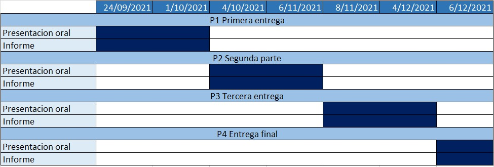

### Marco Teorico

Nuestro estudio se realizará a partir de una base de datos pública extraida del portal web kaggle, datos obtenidos en 2018. El muestreo se basó en el método AF para medir la pobreza multidimensional. La web ofrece esta temática para poder analizarla haciendo uso de la ciencia de datos, el software a utilizar será R y el entorno Restudio.

#### Poblacion Objetivo

Habitantes de los 102 paises sensados

#### Unidad Muestral

Personas que habitan en los paises con mayor índice de pobreza

#### *Cualitativas*

##### *Nominales*

| Variable | Definición |
| --- | --- |
| ISO | ID único para el país |
| Country | Nombre del pais |
| Continent | Continente del pais |

##### *Ordinales*

| Variable | Definición |
| --- | --- |
| MPI Urban | Índice de pobreza multidimensional para áreas urbanas dentro del país |
| MPI Rural | Índice de pobreza multidimensional para áreas rurales dentro del país |

#### *Cuantitativas*

##### *Continuas*

| Variable | Definición |
| --- | --- |
| Headcount Ratio Urban | Índice de recuento de la pobreza (% de la población catalogada como pobre) dentro de las áreas urbanas del país |
| Intensity of Deprivation Urban | Distancia media por debajo de la línea de pobreza de los que figuran como pobres en las zonas urbanas. |
| Headcount Ratio Rural | Índice de recuento de la pobreza (% de la población catalogada como pobre) dentro de las zonas rurales del país |
| Intensity of Deprivation Rural | Distancia media por debajo de la línea de pobreza de los que figuran como pobres en las zonas rurales. |

### Data Frame

#### Variables de estudio

Nuestra base de datos contiene 9 variables, de las cuales tres son Cualitativas nominales, dos Cualitativas ordinales y cuatro Cuatitativas continuas. Asimismo cuenta con 102 observaciones que seran analizadas a continuacion.

#### Analisis de variables

[output not shown]

## Descriptores Numericos

|  | Headcount Ratio Urban | Intensity of Deprivation Urban | MPI Urban |
| --- | --- | --- | --- |
| Mean | 16.80980 | 41.678431 | 0.0783431 |
| Std.Dev | 18.49845 | 5.135908 | 0.0936927 |
| Min | 0.00000 | 33.300000 | 0.0000000 |
| Median | 8.40000 | 41.550000 | 0.0345000 |
| Max | 82.50000 | 55.700000 | 0.4590000 |
| N.Valid | 102.00000 | 102.000000 | 102.0000000 |
| Pct.Valid | 100.00000 | 100.000000 | 100.0000000 |

|  | Headcount Ratio Rural | Intensity of Deprivation Rural | MPI Rural |
| --- | --- | --- | --- |
| Mean | 40.03618 | 46.824510 | 0.2146765 |
| Std.Dev | 33.27071 | 8.783191 | 0.2012083 |
| Min | 0.09000 | 33.300000 | 0.0000000 |
| Median | 36.05500 | 44.800000 | 0.1600000 |
| Max | 96.92000 | 69.500000 | 0.6690000 |
| N.Valid | 102.00000 | 102.000000 | 102.0000000 |
| Pct.Valid | 100.00000 | 100.000000 | 100.0000000 |

## Figuras de merito graficas

Usamos una gráfica de Boxplot, en ella podemos observar datos atipicos apartir de 0.3 hasta 0.5 aproximadamente y eso se debe a que muy pocos de los paises evaluados en la zona urbana presentan pobreza y contrastando esta idea podemos ver que el RIQ se centra mas entre 0 a 0.12 donde se encuentra la mayor cantidad de paises para la zona urbana además tenemos una mediana de 0.0345

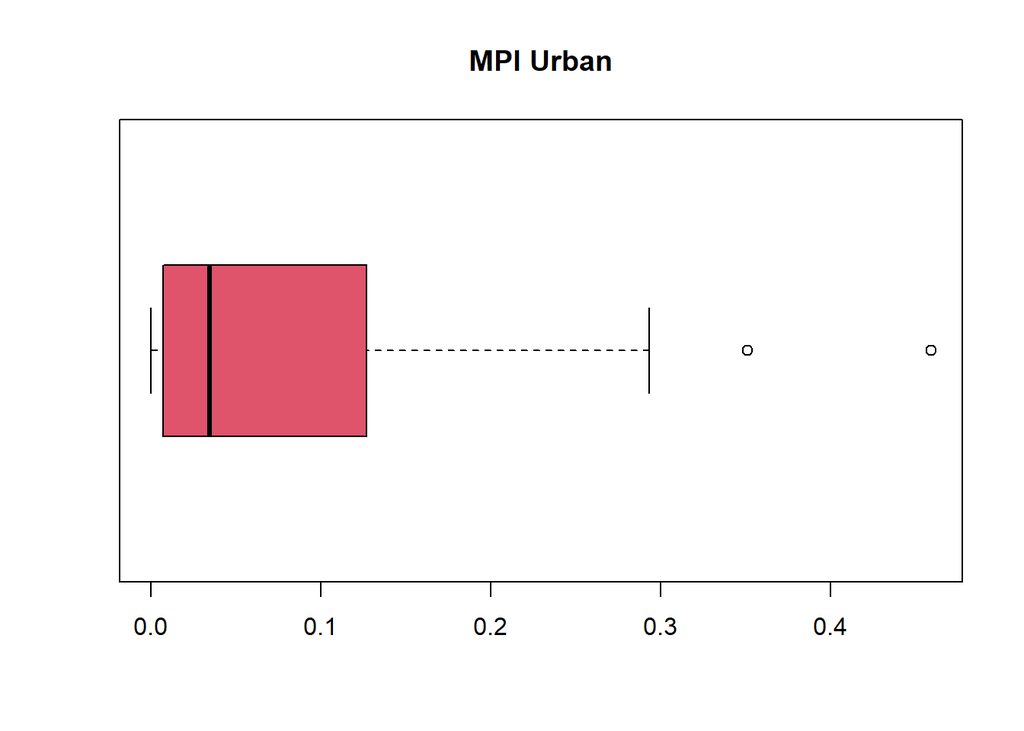

mas de 50 paises estan dentro del ratio mas bajo de pobreza urbana y ademas la grafica decrece cada ves que aumenta la pobreza, solo 1 país presenta un alto indice de pobreza urbana

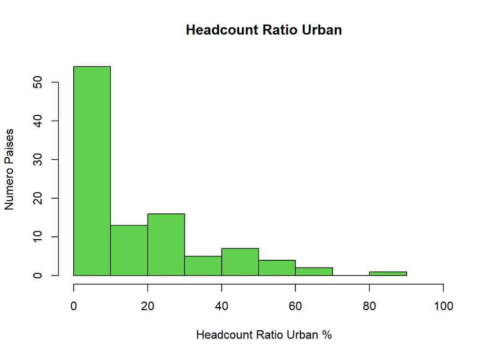

En el caso de extrema pobreza para la zona urbana la mayor cantidad de paises se encuentra en un rango de 35% a 50%, además es poco probable que un país tenga mas del 50% en el índice de extrema pobreza urbana.

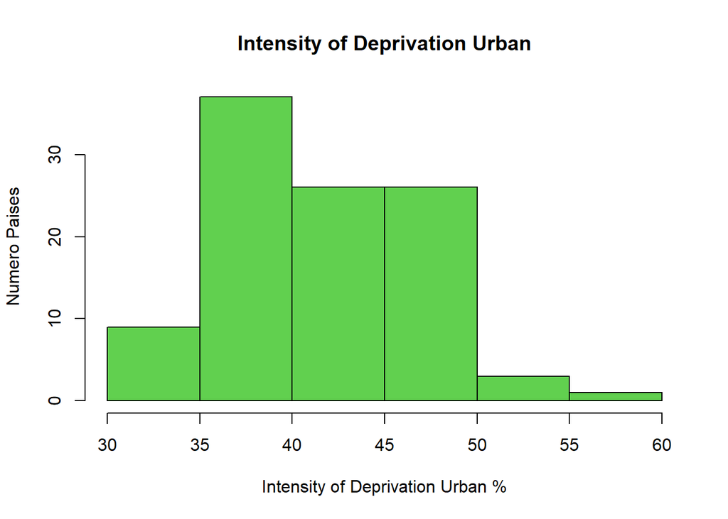

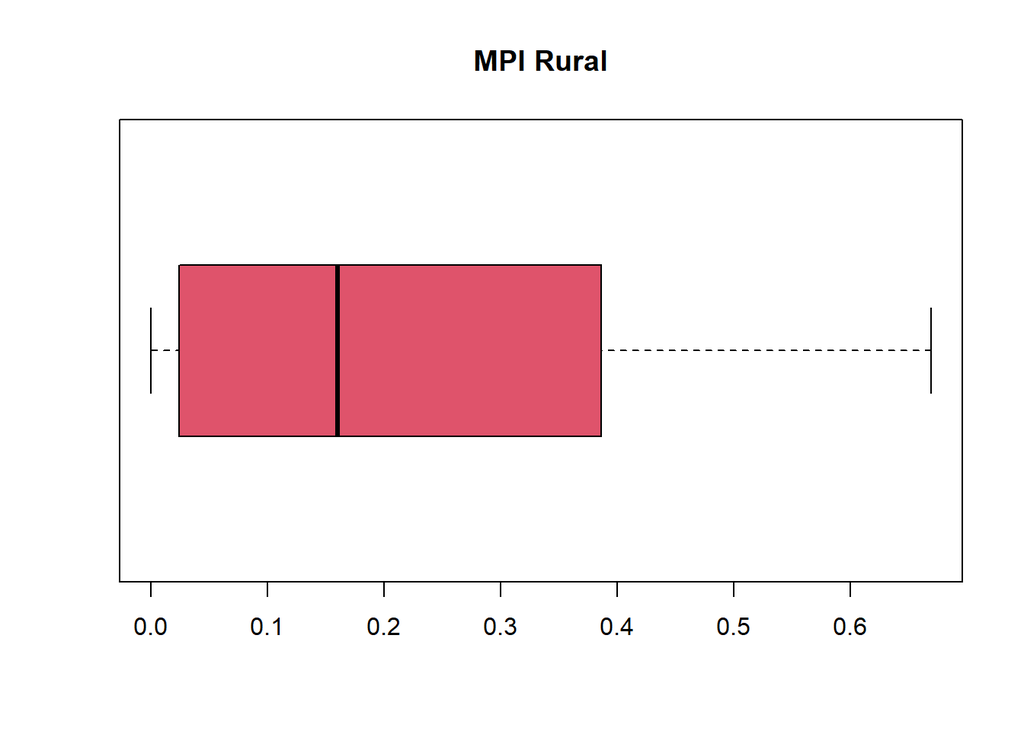

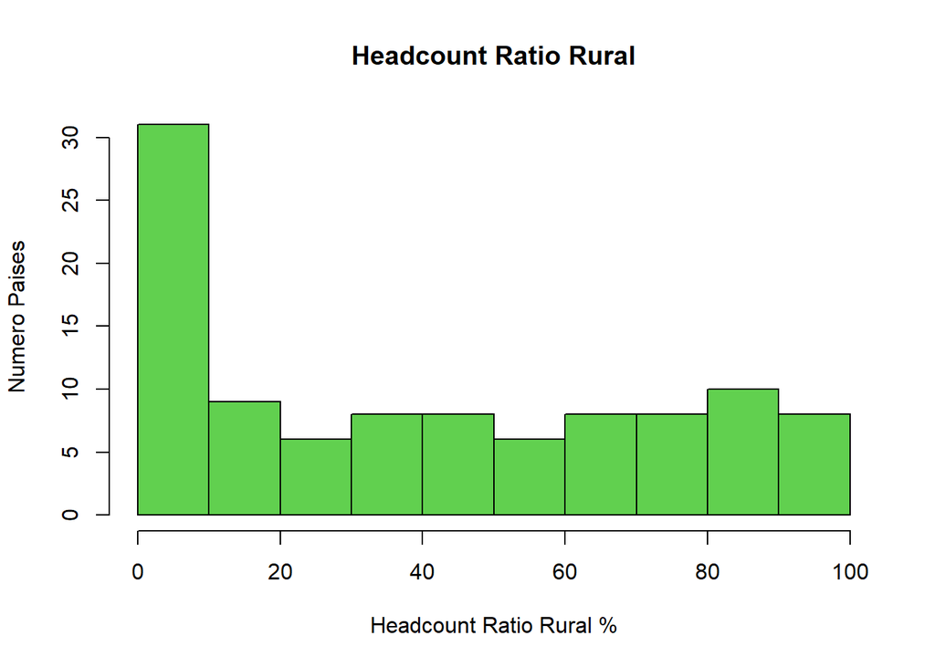

Se evidencia una mayor cantidad de paises en el intervalo de 40% a 45%. Además en el intervalo de 45% a 60% se encuentran 45 paises aproximadamente.

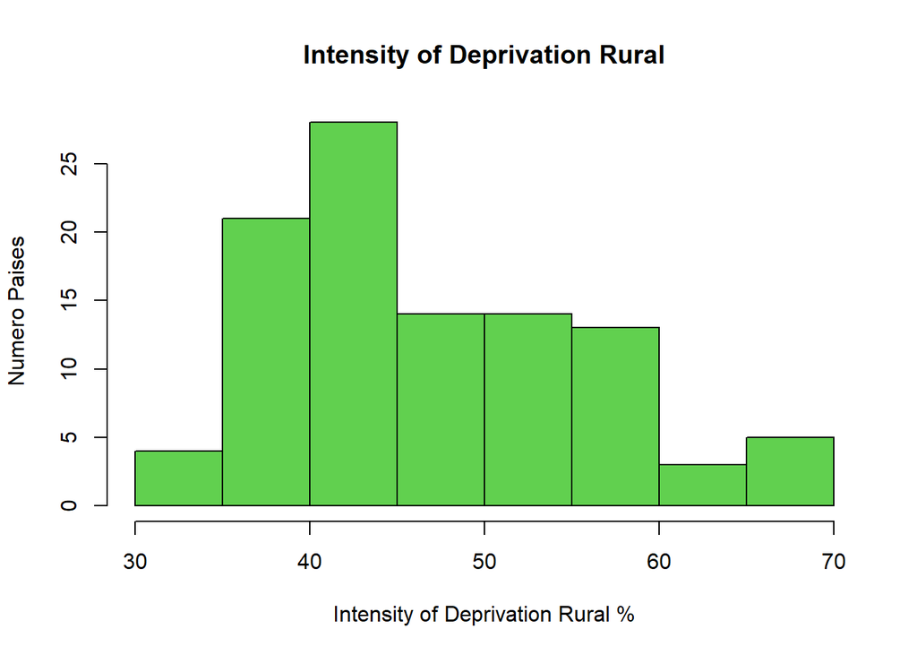

Grafica paises vs continentes ,nos puede ayudar para poder apreciar con mayor exactitud la proporcion de paises por continentes

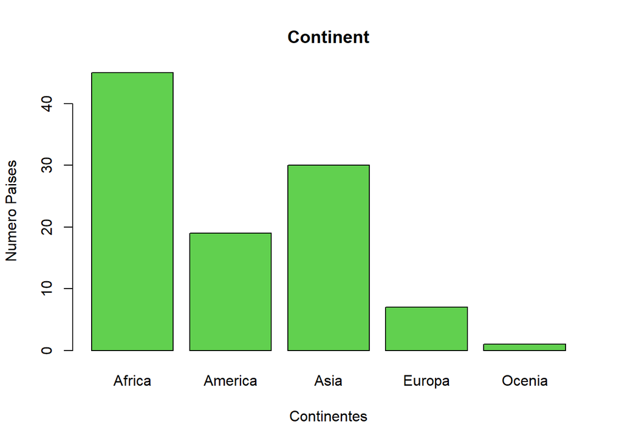

## Modelos de variables aleatorias

Headcount Ratio Urban : Representa el Índice de recuento de la pobreza (% de la población catalogada como pobre) dentro de las áreas urbanas del país. Es una variable aleatoria continua porque puede obtener infinitos valores en el rango de 0% a 82.5%.

Headcount Ratio Rural: Representa el Índice de recuento de la pobreza (% de la población catalogada como pobre) dentro de las áreas rurales del país. Es una variable aleatoria continua porque puede obtener infinitos valores en el rango de 0% a 100%.

Amabas pueden ser modelada por una distribución exponencial ya que la variable es mayor que cero, y sus gráfica se asemeja a una distribución exponencial.

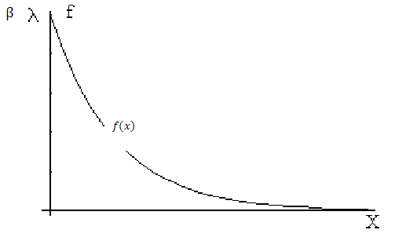

La distribución exponencial para una variable aleatoria con parámetro ‘B’ es X∼Exp(B). Además se sabe que el parámetro es B=E(x), y este se puede estimar mediante el promedio de los valores.

Para la variable Headcount Ratio Urban el parámetro B es igual a 16.81.

Para la variable Headcount Ratio Rural el parámetro B es igual a 40.04.

## Modelos de variables aleatorias

Intensity of Deprivation Urban: Representa el Indice de pobreza extrema en la zona urbana. Es una variable aleatoria continua porque puede obtener infinitos valores en el rango de 33% a 56%

Ambas puede ser modeladas con distribucion gamma ya que las graficas se asemejan.

La distribución gamma para una variable aleatoria con parámetros ‘α,B’ es X∼Gamma(α,B). Además se sabe que el parámetro es B=VAR(x)/mean(x) y α=mean(x)/B.

Para la variable Intensity of Deprivation Urban el parámetro B es igual a 0.63 y el parametro α=65.85.

Para la variable Intensity of Deprivation Rural el parámetro B es igual a 1.65 y el parametro α=28.42.

## Preguntas e hipotesis

[output not shown]

## Relacion entre variables

La gráfica representa la proporción entre el indice de pobreza multidimensional para áreas rurales y el indice de pobreza urbano, en Africa y Asia, siendo estos los continentes con más países en la lista. En esta gráfica se observa una tendencia ascendente, en la que claramente se pude ver que los países de Africa cuentan con indices de pobreza mayores a los países de Asia. Asimismo, la gráfica cuenta con una correlación positiva, lo cual quiere decir que a medida que aumentan los MPI urbanos, aumentan los MPI rurales, en otras palabras mientas un país es más pobre en su zona urbana, lo será aun más en su zona rural.

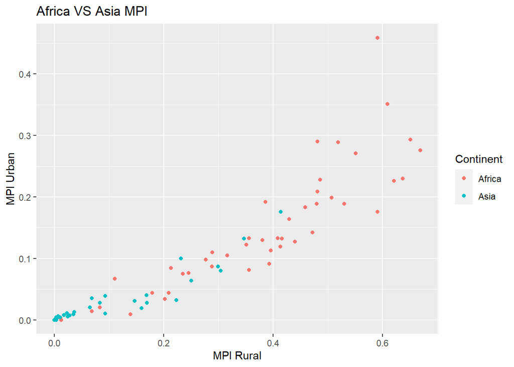

## Relacion entre variables

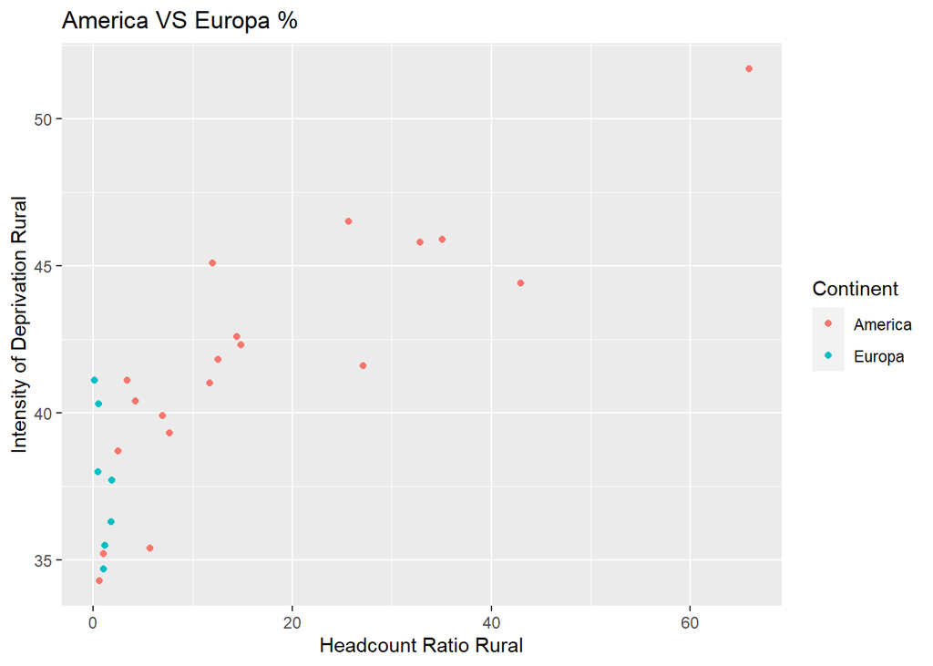

## Relacion entre variables

La gráfica representa la relación entre porcentaje de personas pobres y el porcentaje de personas extremadamente pobres, en Africa y Asia. En esta gráfica se observa una tendencia ascendente, en la que claramente se pude ver que los países de Africa cuentan con indices de pobreza mayores a los países de Asia. Asimismo, la gráfica cuenta con una correlación positiva, lo cual quiere decir que a medida que aumenta el indice de recuento de la pobreza rural (HRR), aumenta la la intensidad de deprivación (IDR).

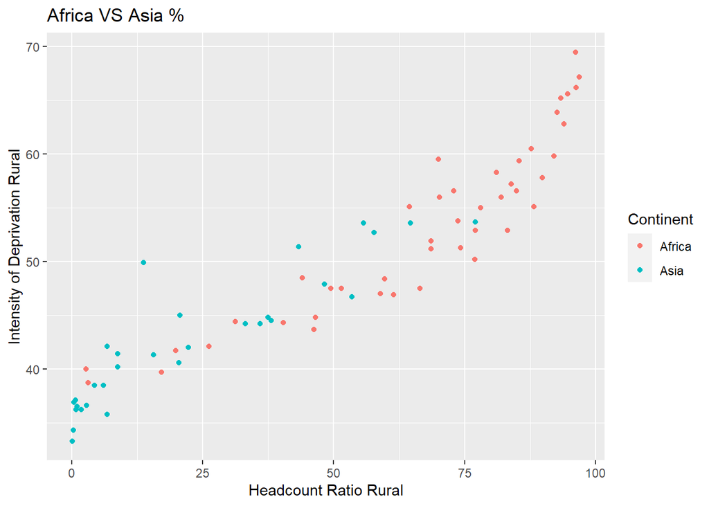

## HIPOTESIS 1

$H_0:$ El promedio de la Intensidad de deprivacion urbana (IDU) es mayor igual al promedio de la Intensidad de deprivacion rural (IDR).

$H_{0}:\mu >= 46.8$

$H_1:$ El promedio de la Intensidad de deprivacion urbana (IDU) es menor al promedio de la Intensidad de deprivacion rural (IDR).

$H_{1}:\mu < 46.8$

Nivel de confianza= 98% Tamaño muestra=102 Intervalo de confianza media=[-Inf, 42.73649] En este caso nuestra variable no tiene una distribucion normal, pero la hemos aproximada para poder generar una hipotesis.

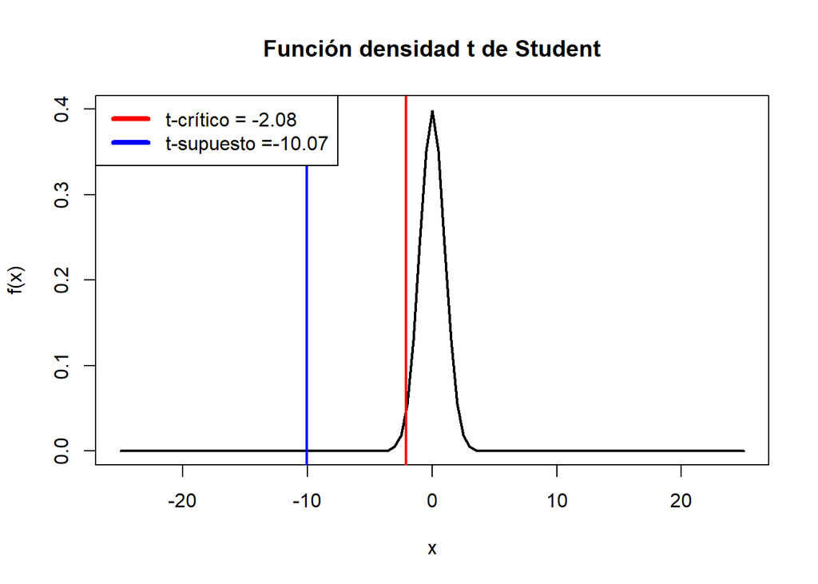

## INTERVALOS DE CONFIANZA HIPOTESIS 1

Intervalo de confianza media = [40.47, 42.89] Error= 1.20

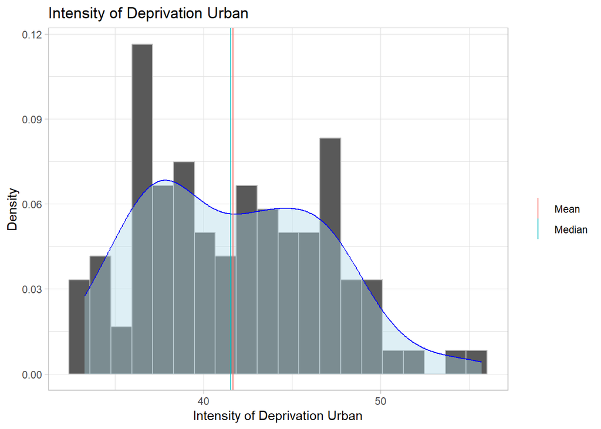

## HIPOTESIS 2

$H_0:$ La varianza de la Intensidad de deprivacion rural (IDU) es mayor igual al promedio de la Intensidad de deprivacion urbana (IDR).

$H_{0}:S^2 >= 26.38$

$H_1:$ La varianza de la Intensidad de deprivacion rural (IDU) es menor al promedio de la Intensidad de deprivacion urbana (IDR).

$H_{1}:S^2 < 26.38$

Nivel de confianza= 99.9% Tamaño muestra=102 Intervalo de confianza media=[-Inf, 49.58387] En este caso nuestra variable no tiene una distribucion normal, pero la hemos aproximada para poder generar una hipotesis.

```
## [1] 26.38
```

```
## [1] 45.10086
```

```
## [1] 48.54816
```

```
## [1] 1.723652
```

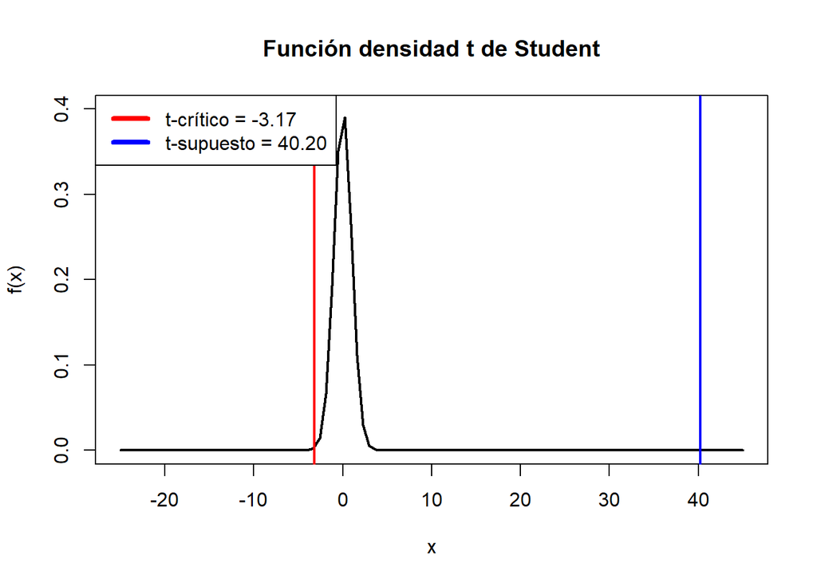

## INTERVALOS DE CONFIANZA HIPOTESIS 2

Intervalo de confianza media = [45.10, 48.55] Error= 1.72

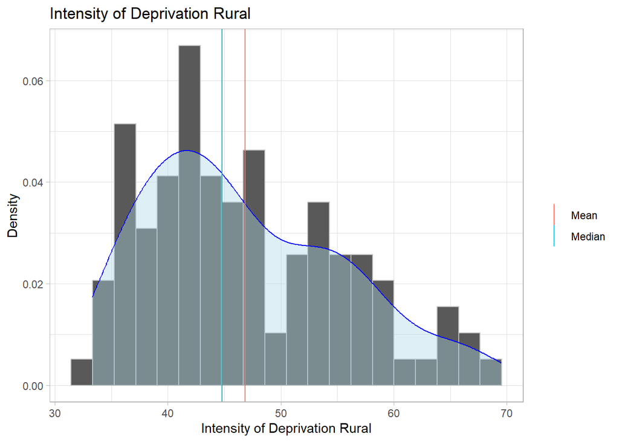

## HIPOTESIS 3

$H_0:$ El promedio del ratio de pobreza rural (HCR) es mayor igual al promedio del ratio de pobreza urbana (HCU).

$H_{0}:\mu >= 16.8$

$H_{1}:\mu < 16.8$

```
## [1] -2.080612
```

```
## [1] -2.053195
```

```
## [1] 32.24901
```

```
## [1] 47.82334
```

```
## [1] 7.787167
```

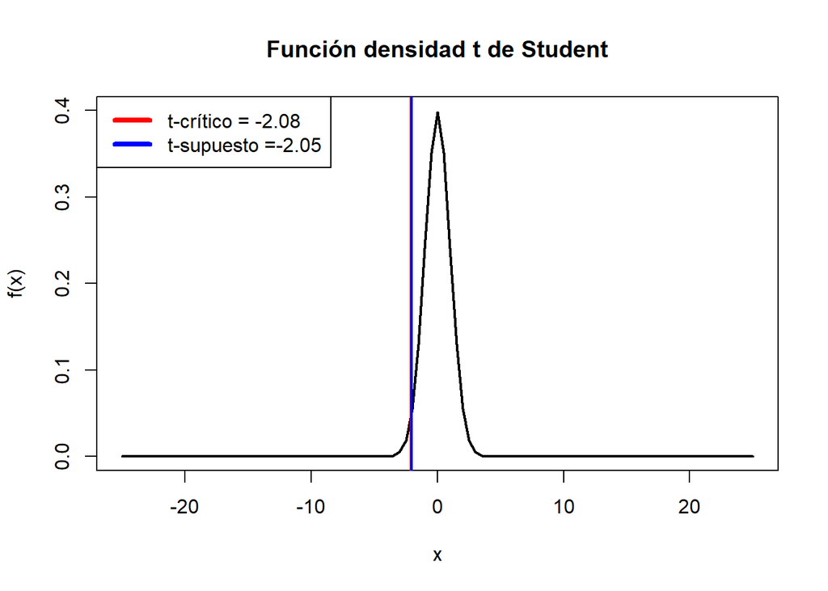

Intervalo de confianza media = [32.24, 47.83] Error= 7.79

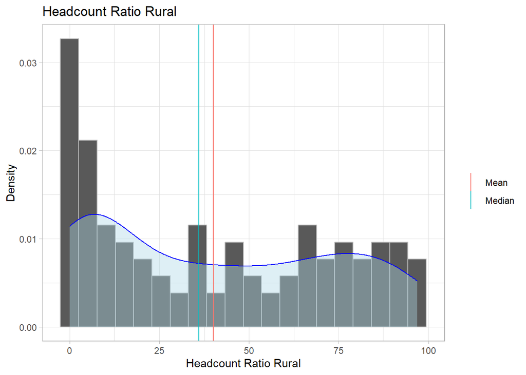

## REGRESION 1

En la siguiente regresión se muestra la relación entre la variable Intensity of Deprivation Rural (IDR) que representará la variable dependiente “y” y la variable Headcount Ratio Rural (HRR) que será la variable independiente “x” en los continentes de Asia y Africa.

#### Correlación entre las variables

La correlacion entre las variables Intensity of Deprivation Rural y Headcount Ratio Rural en los continentes de Asia y Africa, presentan una correlacion porsitiva de 0.94. Al ser cercana a 1 indica que estas variables tienen una proporcionalidad directa o positiva. Se considera que la correlación entre estas variables es fuerte ya que es mayor a 0.7.

#### Coeficientes de regresión

Aplicando la funcion summary obtenemos: ßo = 36.29 ß1 = 0.26

$y(x)=ß0+ß1x$  
$y(x)=36.29+0.26x$

#### Coeficientes de regresión

Asimismo, con la funcion summary obtenemos el valor del R-cuadrado es 0.88, el cual indica un buen ajuste del modelo lineal, siendo $R^2$ mayor a 0.7 y cercano a 1; explicando la variacion total de la variable Intensity of Deprivation Rural en los continentes de Asia y Africa.

#### Prueba de hipótesis para el Interceptos

#### ßo

Ho: ßo = 0 H1: ßo ≠ 0

#### ß1

Ho: ß1 = 0 H1: ß1 ≠ 0

#### Gráfica de Regresión

La variable Intensity of Deprivation Rural (IDR) que representará la variable dependiente “y” y la variable Headcount Ratio Rural (HRR) la variable independiente “x” en Asia y Africa.

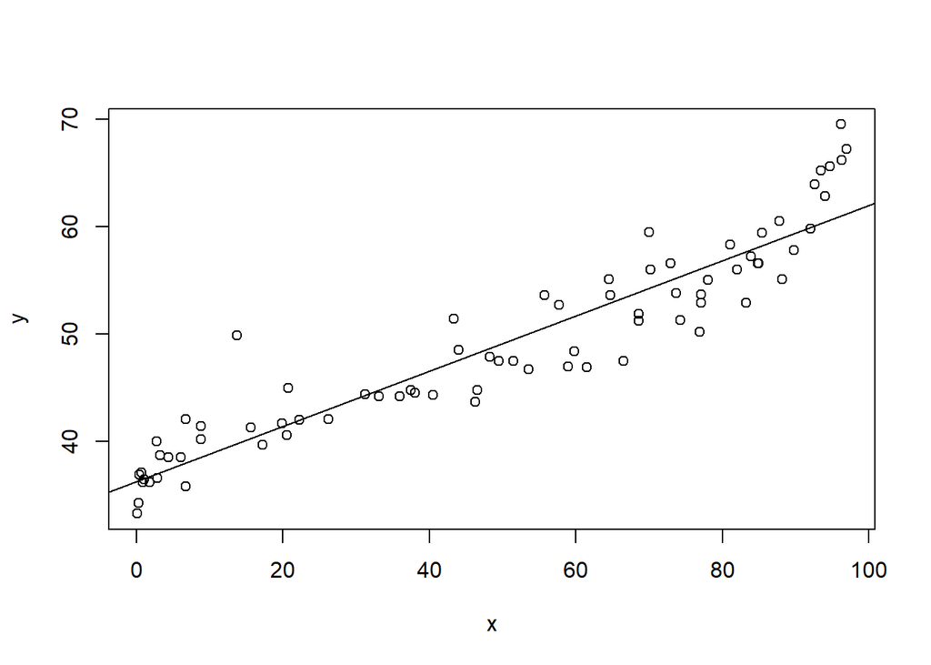

Utilizamos este modelo de regresion lineal, pues consideramos que conforme la Intensidad de Deprivacion Rural (IDR) incrementa, el Ratio de Pobreza Rural aumenta. Analizamos el p-valor del modelo siendo este muy pequeño y menor a la significancia, podemos concluir que el modelo es significativo.

## REGRESION 2

#### Correlación entre las variables

La correlacion entre las variables MPI Rural y MPI Urban en los continentes de Asia y Africa, presentan una correlacion porsitiva de 0.91. Al ser cercana a 1 indica que estas variables tienen una proporcionalidad directa o positiva. Se considera que la correlación entre estas variables es fuerte ya que es mayor a 0.7.

#### Prueba de hipótesis para el Interceptos

#### ßo

Ho: ßo = 0 H1: ßo ≠ 0

#### ß1

Ho: ß1 = 0 H1: ß1 ≠ 0

#### Gráfica de Regresión

La variable MPI Urban (MPU) que representará la variable dependiente “y” y la variable Headcount MPI Rural (MPU) la variable independiente “x” en Asia y Africa.

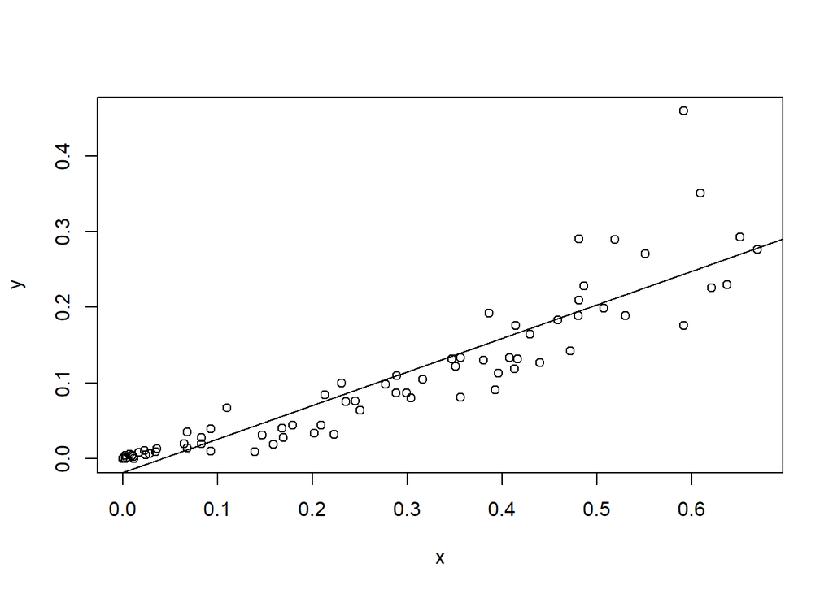

Utilizamos este modelo de regresion lineal, pues consideramos que conforme el MPI Urbano (MPU) incrementa, el el MPI Rural (MPR) aumenta. Analizamos el p-valor del modelo siendo este muy pequeño y menor a la significancia, podemos concluir que el modelo es significativo.

## REGRESION 3

#### Prueba de hipótesis para el Interceptos

#### ßo

Ho: ßo = 0 H1: ßo ≠ 0

#### ß1

Ho: ß1 = 0 H1: ß1 ≠ 0

#### Gráfica de Regresión

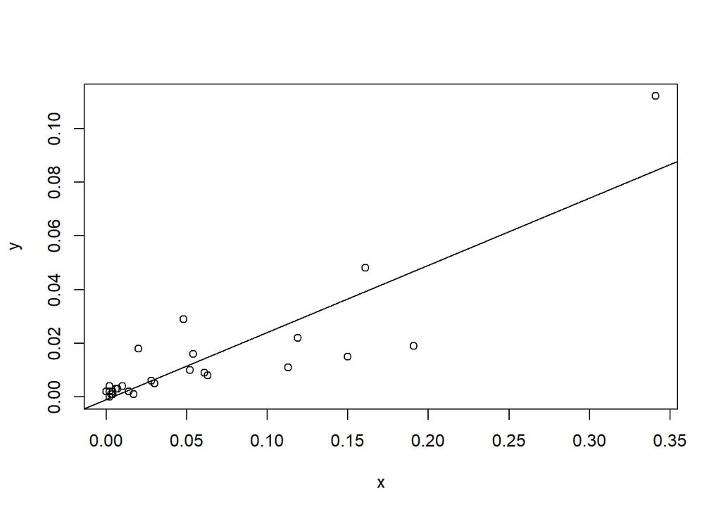

Utilizamos este modelo de regresion lineal, pues consideramos que conforme MPI Urban incrementa, el MPI Rural aumenta. Analizamos el p-valor del modelo siendo este muy pequeño y menor a la significancia, podemos concluir que el modelo es significativo

## Bibliografia

[Base de datos]https://www.kaggle.com/search

[Uso de comandos]https://yihui.org/knitr/options/